# Part 2: Pseudotime Analysis with Monocle3 - Launonen et al., 2024

```r
# load required packages
require(dplyr)
require(Seurat)
require(ggplot2)
require(monocle3)
require(data.table)
require(SeuratWrappers)

setwd('/Users/abba5hahroze/Desktop/Rayca/')
```

```r
object <- readRDS('rayca_immune_singlecell_seurat_object.rds')
```

#### Convert the Seurat object to a CDS and cluster to identify partitions of cells. These are groups with cells that are close in proximity in UMAP space. The T cell population is partition 1.

```r
cds <- object %>% as.cell_data_set() %>% cluster_cells()
```

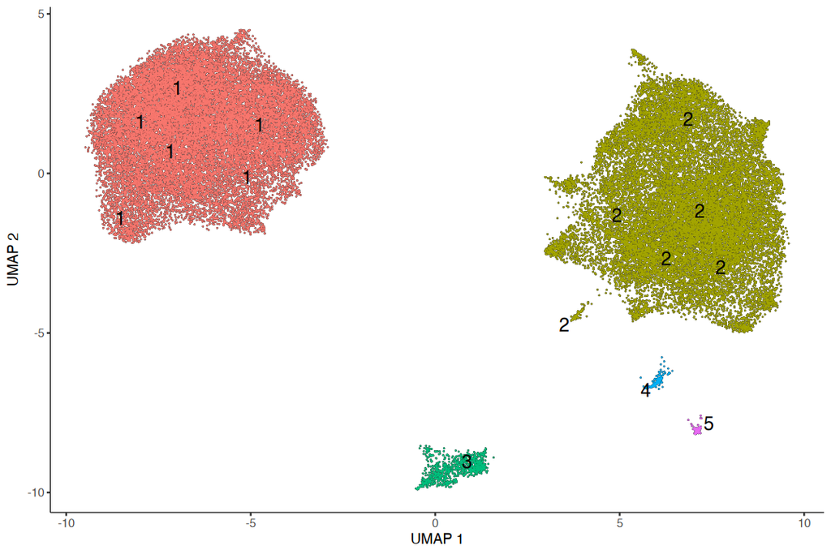

```r
options(repr.plot.width=9, repr.plot.height=6)

plot_cells(cds, color_cells_by='partition', show_trajectory_graph=FALSE, group_label_size=5, cell_size=0.2)
```

#### Here, I filter the cds object to only consider the T cell population. I am also filtering to only consider top variable genes as these typically contain the most information and will make the resource requirements more manageable.

```r
cells.use <- names(partitions(cds)[which(partitions(cds) == 1)])
```

```r
cds <- object %>% subset(cells=cells.use, features=VariableFeatures(object)) %>% as.cell_data_set()
```

#### Cluster cells and learn the principal graph which is essential for building trajectories in monocle3.

```r
cds <- cds %>% cluster_cells() %>% learn_graph()
```

#### Define a function to locate the root that serves as the starting point of the trajectory. This function was borrowed from the monocle3 tutorial. I am setting the early group as the chemo-naive in order to map the progression to the exhausted state post-chemotherapy.

```r
# Monocle3 method for calculating the root principal node
get_root_principal_node <- function(cds, early_group) {
  cell_ids <- which(colData(cds)$treatment_stage == early_group)

  closest_vertex <- cds@principal_graph_aux[['UMAP']]$pr_graph_cell_proj_closest_vertex
  closest_vertex <- as.matrix(closest_vertex[colnames(cds), ])

  root <- igraph::V(principal_graph(cds)[['UMAP']])$name[
    as.numeric(names(which.max(table(closest_vertex[cell_ids,]))))
  ]
  return(root)
}
```

#### The article mentions IFNG as a marker for cytotoxicity. I'm locating the cell with the highest expression of this gene and using it as the root cell to build the trajectory.

```r
# Calculate the root cell using IFNG expression
ifng_values <- Matrix::as.matrix(exprs(cds)['IFNG', ])
ifng_values <- as.data.frame(ifng_values)
setDT(ifng_values, keep.rownames=TRUE)
setorder(ifng_values, -V1)
```

#### Calculate pseudotime and visualize. Here I'm comparing two different methods of choosing the root node. On the left is the method provided by Monocle3 authors which is oddly showing pseudotime in reverse where cells from IDS samples are at the start. Using the cell with the highest expression of IFNG, a marker for T cell cytotoxicity, returns pseudotime in the expected direction. I'm choosing to proceed with the version on the right.

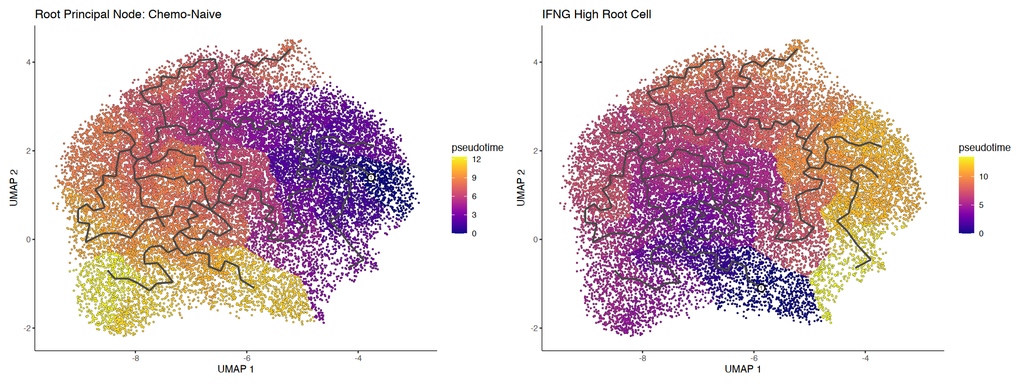

```r
options(repr.plot.width=16, repr.plot.height=6)

cds <- order_cells(cds, root_pr_nodes=get_root_principal_node(cds, early_group='chemo-naive'))
p1 <- plot_cells(cds, color_cells_by='pseudotime', label_cell_groups=FALSE, label_leaves=FALSE, label_branch_points=FALSE, cell_size=0.35)
p1 <- p1 + ggtitle('Root Principal Node: Chemo-Naive')

cds <- order_cells(cds, root_cells=ifng_values[V1 == max(V1)][, rn])
p2 <- plot_cells(cds, color_cells_by='pseudotime', label_cell_groups=FALSE, label_leaves=FALSE, label_branch_points=FALSE, cell_size=0.35)
p2 <- p2 + ggtitle('IFNG High Root Cell')

p1 + p2
```

#### Here, I'm performing a quick logisitic regression where pseudotime is the predictor and treatment stage is the outcome. This will statistically validate that pseudotime is measuring the change between treatment stages and direction. Results show the odds of a cell being IDS increase by ~1.08% for every unit increase in pseudotime.

```r
x <- data.frame(pseudotime=pseudotime(cds), treatment_stage=colData(cds)$treatment_stage)

x <- x[is.finite(x$pseudotime), ]
x$treatment_stage <- factor(x$treatment_stage, levels=c('chemo-naive', 'IDS'))

model <- glm(treatment_stage ~ pseudotime, data=x, family=binomial)

summary(model)
```

```
Call:
glm(formula = treatment_stage ~ pseudotime, family = binomial,
    data = x)

Coefficients:
            Estimate Std. Error z value Pr(>|z|)
(Intercept) 0.403537   0.033474  12.055   <2e-16 ***
pseudotime  0.010765   0.004462   2.413   0.0158 *
---
Signif. codes:  0 ‘***’ 0.001 ‘**’ 0.01 ‘*’ 0.05 ‘.’ 0.1 ‘ ’ 1

(Dispersion parameter for binomial family taken to be 1)

    Null deviance: 32433  on 24370  degrees of freedom
Residual deviance: 32427  on 24369  degrees of freedom
AIC: 32431

Number of Fisher Scoring iterations: 4
```

#### Visualize the results of the Logistic Regression - Probability of a cell being in the IDS group goes up as pseudotime increases.

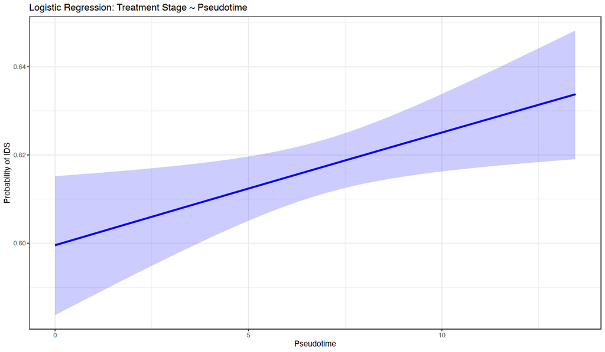

```r
pred <- predict(model, newdata=x, type='link', se.fit=TRUE)
x$fit <- pred$fit
x$se.fit <- pred$se.fit

x$predicted <- plogis(x$fit)
x$lower <- plogis(x$fit - 1.96 * x$se.fit)
x$upper <- plogis(x$fit + 1.96 * x$se.fit)

# Visualize the results
ggplot(x, aes(x=pseudotime, y=predicted)) +
  geom_line(color='blue', size=1) +
  geom_ribbon(aes(ymin=lower, ymax=upper), fill='blue', alpha=0.2) +
  labs(x='Pseudotime', y='Probability of IDS',
       title='Logistic Regression: Treatment Stage ~ Pseudotime') +
  theme_bw()
```

#### Fit GLM for each gene as a function of pseudotime to find genes that vary along the trajectory. Genes increasing with pseudotime should be markers for exhausted T cells post-chemotherapy. I will plot the top 6 with the most significant q-values and largest normalized effect scores.

```r
pseudotime_effects <- cds %>%
                fit_models(model_formula_str='~pseudotime') %>% coefficient_table() %>%
                filter(term == 'pseudotime' & q_value < 0.05) %>% arrange(q_value) %>%

                as.data.table()

setorder(pseudotime_effects, q_value, -normalized_effect)
top_genes <- pseudotime_effects[1:6][, gene_id]
```

```r
setorder(pseudotime_effects, q_value, -normalized_effect)
top_genes <- pseudotime_effects[1:6][, gene_id]
```

```r
cds_subset <- cds[rownames(rowData(cds)) %in% top_genes, ]
rowData(cds_subset)$gene_short_name <- rownames(rowData(cds_subset))
```

#### It looks like 5 of the top 6 genes are downregulated as cells progress from a chemo-naive to exhausted state. What's interesting is increased expression of IL7R as cells transition out of the cytotoxic state. A quick literature search shows that decreased expression of IL7R is associated with exhausted T cells. However, some articles point to a more "stem-like" population of T cells that retains expression of IL7R which is correlated with survival and self-renewal. This analysis could be extended further by using pseudotime to predict functional relationships, identifying potential targets.

##### https://pmc.ncbi.nlm.nih.gov/articles/PMC7049579/

##### https://jitc.bmj.com/content/jitc/10/Suppl_2/A861.full.pdf

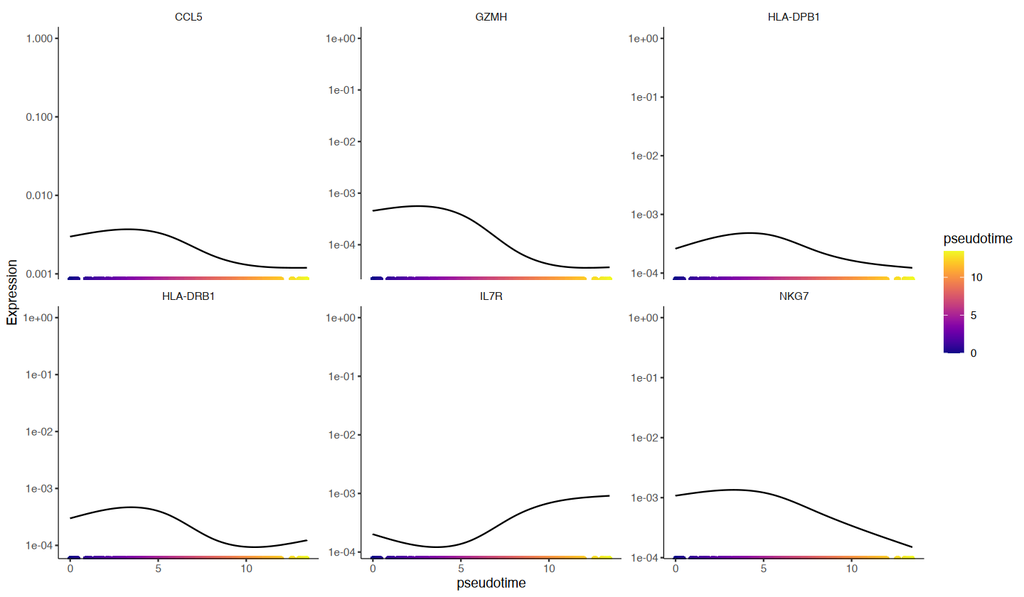

```r
options(repr.plot.width=12, repr.plot.height=7)

plot_genes_in_pseudotime(cds_subset, color_cells_by='pseudotime', nrow=2, ncol=3) +
    theme(axis.title.x.top=element_text(size=10))
```